# Correspondence Analysis

Enquye Negash

March 22, 2015

## Large Mammal Evidence for the Paleoenvironment of the Upper Laetolil and Upper Ndolanya Beds of Laetoli, Tanzania (Denise Su., 2011)

### Paper Summery

This paper tries to give paleoenvironmental interpretations of Laitoli, Tanzania. There has been contradictions in previous environmental interpretations in Laitoli and different proxies have resulted in different results and interpretations. The paper tries to give Paleoenvironmental interpretations by studying the fossil fauna community from the different stratigrapic levels of the Upper Laitoli beds (ULB) and Upper Ndolanya beds(UNB) and comparing it with modern faunal communities and by looking at the relative abundence of indicator species(Bovids) in the different levels of the Laitoli beds. Results of the study indicates that the Paleoenvironment of Laitoli was a mosaic environmentthat shows a shift in ecological conditions from more wooded to relatively more open conditions.

## Read in the data

```r
Bovid.data<-read.csv(file="http://hompal-stats.wabarr.com/datasets/Su_2011_bovid_data.csv")

head(Bovid.data)
```

```
##                  X below.T3 T3.to.T5 above.T5 UNB
## 1     Aepycerotini     10.0       23      6.0   0
## 2 aff. antilopini?      7.0        3      4.0   0
## 3      Alcelaphini     29.0        8     29.0  54
## 4       Antilopini      8.0        7     12.0  24
## 5           Bovini      0.3        0      0.8   2
## 6    Celphalophini      0.5        1      0.5   0
```

The data shows the percentages of the bovid tribes in the different stratigraphic levels. The data has to be formatted and chaged into a contingency table.

```r
rownames(Bovid.data) <- Bovid.data[ ,1]

rownames(Bovid.data)
```

```
##  [1] "Aepycerotini"     "aff. antilopini?" "Alcelaphini"
##  [4] "Antilopini"       "Bovini"           "Celphalophini"
##  [7] "Hippotragini"     "Brabovus"         "Neotragini"
## [10] "Tragelaphini"     "?Reduncini"
```

```r
Bovid.data.new <- Bovid.data[ ,-1]

head(Bovid.data.new)
```

```
##                  below.T3 T3.to.T5 above.T5 UNB
## Aepycerotini         10.0       23      6.0   0
## aff. antilopini?      7.0        3      4.0   0
## Alcelaphini          29.0        8     29.0  54
## Antilopini            8.0        7     12.0  24
## Bovini                0.3        0      0.8   2
## Celphalophini         0.5        1      0.5   0
```

### Correspondence Analysis

Install the ca package and attach it.

```r
library(ca)

Correspondence.analysis <- ca(Bovid.data.new)

print(Correspondence.analysis)
```

```
##
##  Principal inertias (eigenvalues):
##            1        2        3
## Value      0.309562 0.086549 0.020381
## Percentage 74.33%   20.78%   4.89%
##
##
##  Rows:
##         Aepycerotini aff. antilopini? Alcelaphini Antilopini    Bovini
## Mass        0.096559         0.034662    0.297103   0.126269  0.007675
## ChiDist     0.863581         0.706899    0.548384   0.537553  0.992505
## Inertia     0.072011         0.017321    0.089346   0.036487  0.007561
## Dim. 1     -1.477292        -0.709073    0.976098   0.911589  1.737579
## Dim. 2     -0.798226         1.091306   -0.092936  -0.419851 -0.416624
##         Celphalophini Hippotragini  Brabovus Neotragini Tragelaphini
## Mass         0.004952     0.076752  0.034662   0.304531     0.016588
## ChiDist      0.705288     0.932887  0.957119   0.423036     1.503772
## Inertia      0.002463     0.066795  0.031753   0.054499     0.037512
## Dim. 1      -1.246512    -0.028166 -1.580374  -0.748656     2.401294
## Dim. 2      -0.016426     3.101888 -1.026370  -0.143522    -2.229539
##         ?Reduncini
## Mass      0.000248
## ChiDist   1.734054
## Inertia   0.000744
## Dim. 1    0.195605
## Dim. 2    5.433906
##
##
##  Columns:
##          below.T3  T3.to.T5 above.T5       UNB
## Mass     0.252785  0.250062 0.249567  0.247586
## ChiDist  0.293904  0.770149 0.483534  0.871367
## Inertia  0.021835  0.148319 0.058350  0.187987
## Dim. 1  -0.297105 -1.292938 0.108831  1.499510
## Dim. 2   0.095857 -0.856898 1.598610 -0.843802
```

## Plotting the data

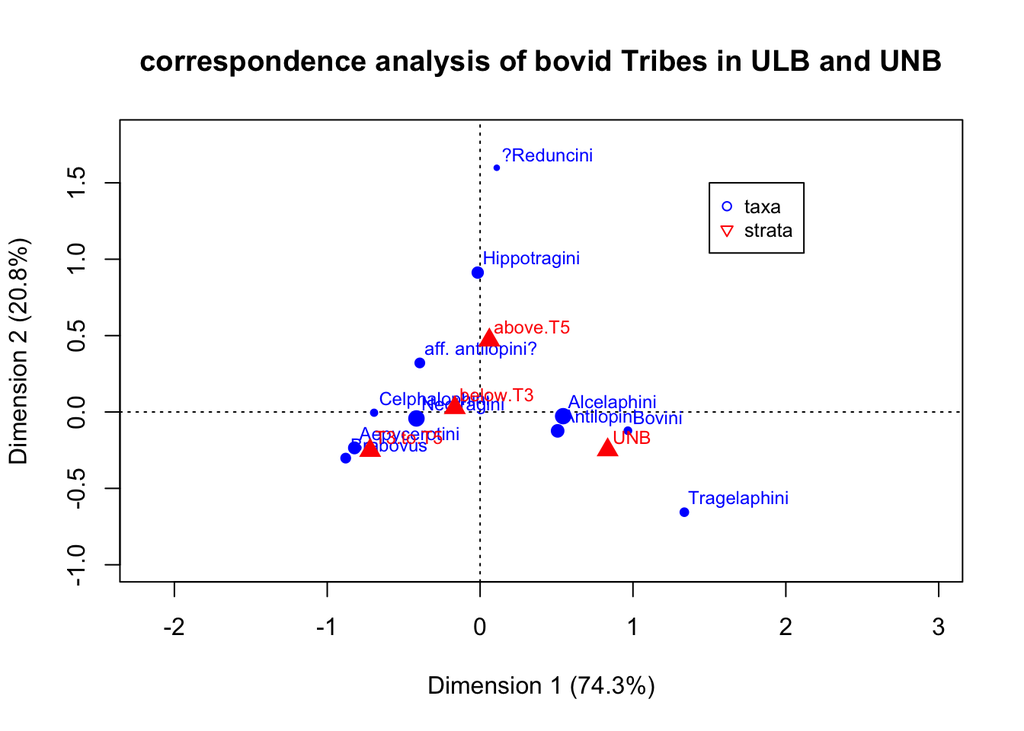

```r
# use the xlim and ylim to zoom in the data and add a legend

plot(ca(Bovid.data.new), mass = TRUE,xlim = c(-1.2,2), ylim = c(-1,1.8),main="correspondence analysis of bovid Tribes in ULB and UNB")

legend(x=1.5,y=1.5,c("taxa", "strata"),cex=.8,pch=c(1,6), col=c("blue","red"))
```

### You Can also make 3D plots

```r
library(rgl)

plot3d.ca(Correspondence.analysis, dim=c(1,2,3))
```

[output not shown]